# Final Project

Kechen Hu

*Source file* ⇒ final_project.Rmd

## Car crash around Washington

### Introduction

In this project I will illustrate some facts about car crashes around Washington area, and analysis some of the reasons that why there are Crashes. (for instance, the distribution of car crashes in Maryland state, the relationship between car crashes and weather, date and specific time of a day.)I found a data set from data.gov, they have some really good data set, if you want to, go check the website out.

So, First of all, I create the table with date and Vehicle body type variable inside and tried to find out the distribution of crashes in terms of time.

```r
library(ggplot2)
library(lubridate)
Crash <- read.csv("Crash_Reporting_-_Drivers_Data.csv")
Vehicle_type<-
  Crash %>%
    mutate(date=as.Date(mdy_hms(Crash.Date.Time))) %>%
    select(date,Vehicle.Body.Type)
```

Here are the top three type of vehicle that the data illustrate to have more crashes than others.

```r
Car<-
  Vehicle_type %>%
  group_by(Vehicle.Body.Type) %>%
  summarize(total=n())
head(arrange(Car,desc(total)),n=3)
```

```
## # A tibble: 3 x 2
##         Vehicle.Body.Type total
##                    <fctr> <int>
## 1           PASSENGER CAR 40472
## 2 (SPORT) UTILITY VEHICLE  5479
## 3            PICKUP TRUCK  2547
```

Then, this is the crashes happened in terms of date. the x-axis is date, and y-axis is number of crashes.

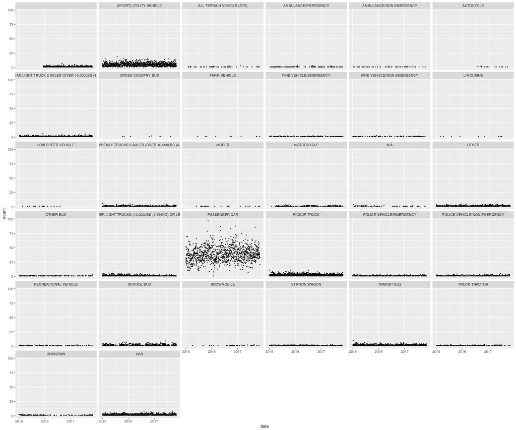

```r
Vehicle_type %>%
  group_by(date,Vehicle.Body.Type) %>%
  summarize(count=n()) %>%
  ggplot(aes(x=date,y=count)) + geom_point(size=0.5) + facet_wrap( ~ Vehicle.Body.Type)
```

From the above graph, we cannot clear see the points (expect for passenger car, maybe because there are just too many of them…), so, I scale the graph a little bit to see more points.

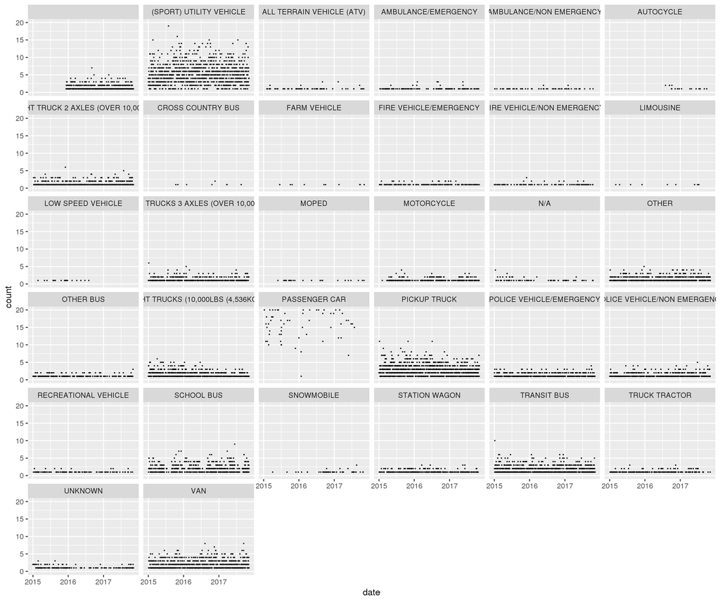

```r
Vehicle_type %>%
  group_by(date,Vehicle.Body.Type) %>%
  summarize(count=n()) %>%
  ggplot(aes(x=date,y=count)) + geom_point(size=0.1) + facet_wrap( ~ Vehicle.Body.Type) + ylim(0,20)
```

So, here we can see that the utility vehicle and pick-up truck are also high intense, although they don’t have as many crashes as passenger car, but still much higher than any other type of cars.

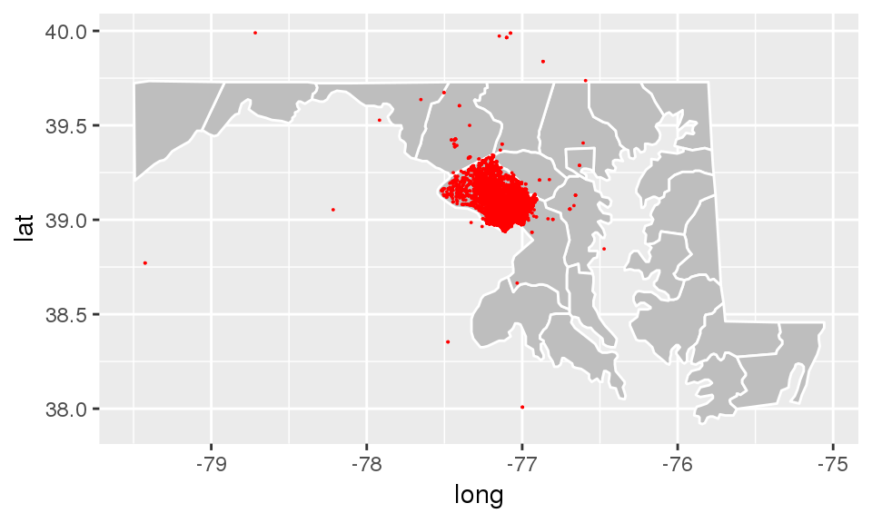

```r
library(maps)
C_map <- map_data("state","Maryland")
counties <- map_data("county")
C_county <- subset(counties, region == "maryland")
map1 <- ggplot(C_county) +
  geom_polygon(aes(x = long, y = lat, group = group), fill = "gray", colour = "white")
map1 + geom_point(data = Crash, aes(x = Longitude, y = Latitude), colour = "red",size=0.01)
```

And this is a state map I created, trying to show all the location of the car crashes in map, so we can see where has the highest probability to have car crashes.(this graph is based on longitude and latitude, so pretty accurate.)

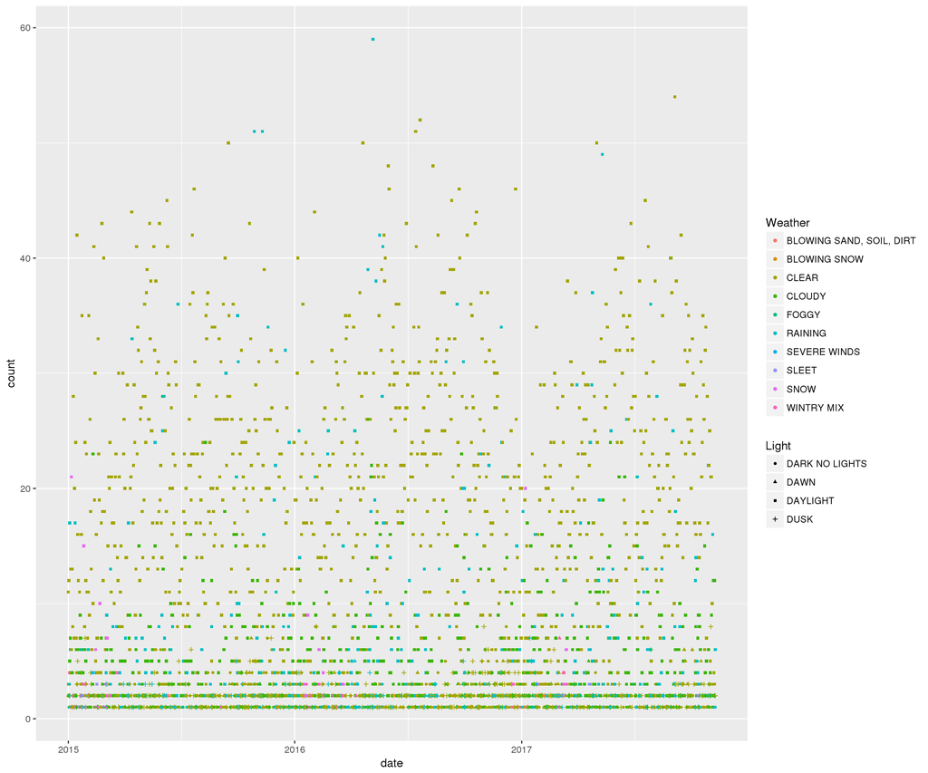

```r
Passenger <-
  Crash %>%
  mutate(date=as.Date(mdy_hms(Crash.Date.Time))) %>%
  select(Vehicle.Body.Type,Weather, Light, date) %>%
  filter(Vehicle.Body.Type== "PASSENGER CAR")
keeps <- levels(Passenger$Weather)
keeps <- keeps[-c(6, 7, 12)]
Passenger %>%
  filter(Weather %in% keeps) %>%
  filter(Light %in% c("DARK NO LIGHTS","DAWN","DAYLIGHT","DUSK")) %>%
  group_by(date,Vehicle.Body.Type, Weather,Light) %>%
  summarize(count=n()) %>%
  ggplot(aes(x=date,y=count,color=Weather,shape=Light)) + geom_point(size=1)
```

From the graph we can see that, for most car crashes, they happen when the weather is clear, which really surprise me a lot. I originally thought that they would happen during some extreme weather conditions. The car crash happened the most between 2016 and 2017 is during raining days, which really make sense. Since the road may be slippery.

### Conclusion

We can see that, for the whole Maryland state, the car crashes most happen around Washington, also, we can conclude following ideas:

1.Passenger car crashes happen the most, followed by (SPORT) UTILITY VEHICLE and Pickup truck.

2.Car crashes most happen in day light.

3.Car crashes most happen during clear weather (which surprise me a lot).